# Cyclistic bike-share analysis case study

### 6.8- distribution end points

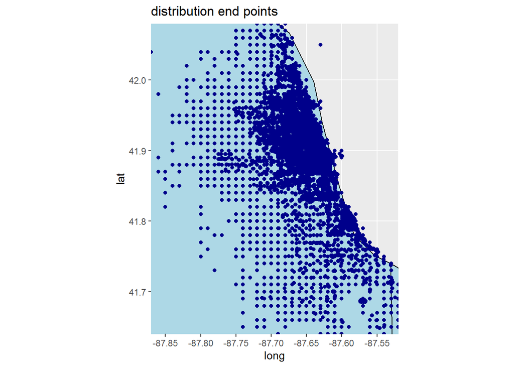

```r
ggplot() +
  geom_polygon( data=MainStates, aes(x=long, y=lat, group=group),
                color="black", fill="lightblue" )+
  geom_point(data=annualtrip, aes(x=end_lng, y= end_lat),color='darkblue')+ coord_sf(xlim = c(xmin, xmax), ylim = c(ymin, ymax), expand = FALSE)+ labs(title = "distribution end points ")
```

```r
rm(MainStates)
```

### 6.9- users

there are two type of users

```r
annualtrip %>% distinct(customer_type)
```

```
## # A tibble: 2 x 1
##   customer_type
##   <chr>
## 1 member
## 2 casual
```

**this steps give you an idea to next steps in clean data**

## 7- how does it help you to answer your questions

start_time ,end_time ==> ride_length(minutes) , week_of_day ==> how difference usual and member users * summary tables row customer_type and columns count_of_tours,min,max,std,var * summary tables row customer_types and columns ride_length values count_of_tours * summary tables row customer_types and columns week_of_day,months and seasons values count_of_tours,avg_ride_length * customer type and bicycle types to attract already customer we don’t need to media digital but in my opinion poster where traffic (in and out ) from station is big (what is better digital or poster ads)??

```r
t <- annualtrip %>%   group_by(start_station_name) %>% drop_na() %>%
   summarise( traffic = n() , lat = mean(start_lat),lng = mean(start_lng))
```

## 8- are there any problem with the data ?

1- there are duplicated data that removed 2- there are a few values end_time < start_time that filter only data that end >start there are ride_length very long communicate with stakeholder !! monitor data is good to ensure data quality 3- data types start_station_id,end_station_id are char it’s a good idea to make another table that include actual stations and their name and here deal only with numbers it’s similar to find and replace and save a lot of storage (future work or next steps) 3- there are stations that may add it recently but there are no info about lng ,lat so that there are a lot of unlabeled (source of error) so that we should ask stakeholder 4- null values there is a way to include this ride to closest stations (future work) this is link to it https://stackoverflow.com/questions/27442506/find-nearest-points-of-latitude-and-longitude-from-different-data-sets-with-diff 5- we notice the traffic is different distribution of stations is important so that we can define our poster location and time of this poster with biggest chance to change mind of our customer (many views winter is different from summer)